# Weibull data-generating process for overall survival

Ajsi Kanapari

2026-10-20

# 1 Aim

This document calibrates and generates the superpopulation used by all simulation scenarios of the main analysis (S0-S4), and the S4 trial pool. It produces:

- `data/dgp_calibration.rda`: calibrated Weibull parameters (`cal`);
- `data/superpopulation_generated_weibull.rda`: the superpopulation;
- `data/trial_pool_s4_generated_weibull_s4.rda`: the S4 trial pool;
- `results/tables/`: Table 1 and Supplementary Tables A1-A2.

Inputs: `config/parameters.R` (design parameters and S4 selection model) and `config/simulation_structure.xlsx` (covariate distributions and prognostic coefficients). The DGP functions are in `functions/dgp_weibull.R` and `function/dgp_s4.R`.

# 2 Why a Weibull model

The control arm must reproduce two clinical targets: a median OS of 7.5 months and a 12-month survival of 0.32. Under an exponential proportional hazards model,
$$S_i(t \mid X_i) = \exp\{-\lambda_0\, t\, \exp(\eta_i)\},$$
the baseline has a single parameter: once the median is fixed, the whole curve is fixed (for $\eta_i = 0$, $S(12) = \exp\{-12 \log 2 / 7.5\}$), so the two targets cannot be matched independently.

The Weibull proportional hazards model adds a shape parameter $k$:
$$S_i(t \mid X_i, Z_i) = \exp\{-\lambda_0\, t^{k} \exp(\eta_i)\},
\qquad
h_i(t \mid X_i, Z_i) = \lambda_0\, k\, t^{k-1} \exp(\eta_i),$$
with $\eta_i = X_i^\top\beta + Z_i\beta_Z$. It reduces to the exponential model for $k = 1$; the hazard increases over time for $k > 1$ and decreases for $k < 1$.

**Calibration.** The marginal control survival is a mixture over the covariate distribution, $S_0(t) = E_X[\exp\{-\lambda_0 t^k \exp(X^\top\beta)\}]$, approximated on a large calibration population by $\widehat S_0(t) = N^{-1} \sum_i \exp\{-\lambda_0 t^k \exp(\eta_{i0})\}$. $\lambda_0$ and $k$ minimise
$$\big[\widehat S_0(t_{0.5,0}) - 0.5\big]^2 +
\big[\widehat S_0(\tau) - S_{0,\tau}^{target}\big]^2,$$
and $\beta_Z$ is then chosen so that $\widehat S_1(t_{0.5,1}) = 0.5$, with $\widehat S_1(t) = N^{-1}\sum_i \exp\{-\lambda_0 t^k \exp(\eta_{i0} + \beta_Z)\}$. $\beta_Z$ is a conditional log-hazard ratio: because of non-collapsibility it differs from the marginal one.

**Event times** are generated by inverse transform sampling:
$$T_i = \left[\frac{-\log U_i}{\lambda_0 \exp(\eta_i)}\right]^{1/k},
\qquad U_i \sim \mathrm{Uniform}(0, 1),$$
with independent uniforms under control and treatment, and a common administrative censoring time $C_i \sim \mathrm{Uniform}(C_{low}, C_{upp})$.

# 3 Setup

```r
library(here)
library(dplyr)
library(tidyr)
library(survival)
library(ggplot2)
library(knitr)

source(here("config/parameters.R"))
source(here("functions/dgp_weibull.R"))
source(here("functions/dgp_s4.R"))
source(here("functions/table_dgp.R"))

dir.create(here("data"), showWarnings = FALSE)
dir.create(here("results/tables"), showWarnings = FALSE, recursive = TRUE)
```

Covariate distributions and prognostic coefficients are read from the S1 sheet (registry row), common to all scenarios. Censoring bounds are read from the trial row and applied to the whole superpopulation, registry included. The S4 sheet only provides the target prevalences of Supplementary Table A2.

```r
read_row <- function(sheet, row) {
  readxl::read_excel(here(PATH_DGP_XLSX), sheet = sheet) |>
    dplyr::filter(parameters == row)
}

reg_params   <- read_row("S1", "registry") |> check_dgp_params()
trial_params <- read_row("S1", "trial")
s4_reg       <- read_row("S4", "registry") |> check_dgp_params()
s4_trial     <- read_row("S4", "trial")    |> check_dgp_params()

dgp_args <- make_dgp_args(reg_params)
```

# 4 Calibration

```r
set.seed(SEED_MASTER)

cal <- do.call(
  calibrate_weibull_DGP,
  c(
    list(
      N_calib          = N_CALIB_MAIN,
      target_median_z0 = TARGET_MEDIAN_Z0,
      target_S0_tau    = TARGET_S0_TAU,
      target_median_z1 = TARGET_MEDIAN_Z1,
      tau              = TAU
    ),
    dgp_args
  )
)


cal$checks |>
  tidyr::pivot_longer(everything(), names_to = "check", values_to = "value") |>
  kable(digits = 4)
```

| check | value |
| --- | --- |
| median_z0_target | 7.5000 |
| median_z0_check | 7.5002 |
| S0_tau_target | 0.3200 |
| S0_tau_check | 0.3200 |
| median_z1_target | 13.0000 |
| median_z1_check | 13.0000 |
| S1_tau_check | 0.5307 |
| deltaS_tau_check | 0.2108 |
| HR_conditional | 0.3557 |
| logHR_conditional | -1.0336 |

```r
save(cal, file = here("data/dgp_calibration.rda"))
```

The calibrated shape is $k =$ 1.879: the individual hazard increases over time. This is a consequence of the calibration constraints, not an assumption on recurrent glioblastoma: high-risk patients leave the risk set early, which flattens the marginal hazard, and the individual hazard must increase to reproduce the marginal targets.

# 5 Superpopulation

The superpopulation is generated in the same random stream as the calibration (no seed reset in between).

```r
superpopulation_generated <- do.call(
  generate_superpopulation,
  c(
    list(
      N                 = N_SUPERPOP_MAIN,
      C_low             = C_low,
      C_upp             = C_upp,
      lambda0           = cal$lambda0,
      weibull_shape     = cal$weibull_shape,
      beta_treatment_OS = cal$beta_treatment_OS
    ),
    dgp_args
  )
)

save(superpopulation_generated,
     file = here("data/superpopulation_generated_weibull.rda"))
```

# 6 S4 trial pool

The S4 trial pool is drawn from the superpopulation with weights $\exp(\eta_{sel})$, where $\eta_{sel}$ is a linear selection score with the log-odds in `S4_SELECTION_COEFS`. The coefficients follow the direction of the target prevalences (S4 sheet) but are attenuated to keep a plausible overlap (Supplementary Table A2). The pool is restricted to $B = 1$ later, when the scenario pools are built.

```r
trial_pool_s4 <- make_s4_trial_pool(
  superpop     = superpopulation_generated,
  N_trial_pool = N_TRIAL_POOL_S4,
  coefs        = S4_SELECTION_COEFS,
  seed         = SEED_MASTER
)

save(trial_pool_s4, file = here("data/trial_pool_s4_generated_weibull_s4.rda"))
```

# 7 Checks

Latent and observed survival in the superpopulation and in the S4 trial pool. The latent quantities use the true event times, the observed ones the Kaplan-Meier estimate under administrative censoring.

```r
km_summary <- function(dat, pop) {
  purrr::map_dfr(c(z0 = "0", z1 = "1"), function(z) {
    fit <- survfit(Surv(dat[[paste0("time_z", z)]], dat[[paste0("event_z", z)]]) ~ 1)
    T_lat <- dat[[paste0("T_true_z", z)]]
    tibble(
      population   = pop,
      arm          = ifelse(z == "0", "Control", "Treatment"),
      median_true  = median(T_lat),
      median_KM    = unname(summary(fit)$table["median"]),
      S_tau_true   = mean(T_lat > TAU),
      S_tau_KM     = summary(fit, times = TAU)$surv,
      prop_events  = mean(dat[[paste0("event_z", z)]])
    )
  })
}

bind_rows(
  km_summary(superpopulation_generated, "Superpopulation"),
  km_summary(trial_pool_s4,             "S4 trial pool")
) |>
  kable(digits = 3)
```

| population | arm | median_true | median_KM | S_tau_true | S_tau_KM | prop_events |
| --- | --- | --- | --- | --- | --- | --- |
| Superpopulation | Control | 7.467 | 7.461 | 0.319 | 0.316 | 0.659 |
| Superpopulation | Treatment | 13.005 | 13.028 | 0.531 | 0.531 | 0.496 |
| S4 trial pool | Control | 9.757 | 9.710 | 0.415 | 0.411 | 0.590 |
| S4 trial pool | Treatment | 16.917 | 16.932 | 0.635 | 0.635 | 0.412 |

# 8 Tables

References are documentation only: they are not used in any computation.

```r
references <- c(
  B              = "Simulation assumption",
  M              = "Liau et al. 2023; Weller et al. 2015",
  pTERT          = "Robinson et al. 2026; Giunco et al. 2024",
  EGFR           = "Robinson et al. 2026",
  g7l10          = "Robinson et al. 2026",
  age            = "Fyllingen et al. 2021",
  sex            = "Fyllingen et al. 2021",
  WHOm2          = "Robinson et al. 2026",
  resection_0    = "Brown et al. 2016; Ringel et al. 2016",
  resection_1    = "Vogelbaum et al. 2022; Ringel et al. 2016",
  resection_2    = "Vogelbaum et al. 2022; Ringel et al. 2016",
  resection_3    = "Vogelbaum et al. 2022; Ringel et al. 2016",
  trt_type_0     = "Robinson et al. 2026",
  trt_type_1     = "Robinson et al. 2026",
  trt_type_2     = "Robinson et al. 2026",
  tumor_size     = "Fyllingen et al. 2021",
  multifocal     = "Robinson et al. 2026",
  localization_0 = "Robinson et al. 2026; Alhalabi et al. 2026",
  localization_1 = "Robinson et al. 2026; Alhalabi et al. 2026",
  localization_2 = "Robinson et al. 2026; Alhalabi et al. 2026",
  localization_3 = "Robinson et al. 2026; Alhalabi et al. 2026",
  localization_4 = "Robinson et al. 2026; Alhalabi et al. 2026",
  localization_5 = "Robinson et al. 2026; Alhalabi et al. 2026"
)
```

## 8.1 Table 1. DGP parameters

```r
tab_dgp_parameters <- table_dgp_parameters(reg_params, references)

tab_dgp_parameters |>
  kable(
    digits    = 3,
    col.names = c("Section", "Covariate", "Prevalence / mean", "SD",
                  "log-HR", "HR", "Note", "Reference"),
    caption   = paste0(
      "Table 1. Registry covariate distributions and prognostic coefficients ",
      "of the Weibull outcome model, common to all scenarios. Extent of ",
      "resection and treatment intensity are ordinal with a linear effect per ",
      "level (per-level log-HR: ", reg_params$beta_resection_OS, " and ",
      reg_params$beta_trt_baseline_OS, "); the log-HR shown for each level is ",
      "the contrast with the reference level. Localization indicators are ",
      "generated independently and have no prognostic effect. Administrative ",
      "censoring: Uniform(", trial_params$C_low, ", ", trial_params$C_upp_trial,
      ") months in both cohorts."
    )
  )
```

| Section | Covariate | Prevalence / mean | SD | log-HR | HR | Note | Reference |
| --- | --- | --- | --- | --- | --- | --- | --- |
| Molecular markers | Brain penetrance (B) | 0.600 | — | -0.300 | 0.741 | — | Simulation assumption |
| Molecular markers | MGMT methylation (M) | 0.460 | — | -0.710 | 0.492 | — | Liau et al. 2023; Weller et al. 2015 |
| Molecular markers | pTERT mutation | 0.784 | — | 0.260 | 1.297 | — | Robinson et al. 2026; Giunco et al. 2024 |
| Molecular markers | EGFR alteration | 0.330 | — | 0.530 | 1.699 | — | Robinson et al. 2026 |
| Molecular markers | Chr7+/Chr10− | 0.342 | — | 0.880 | 2.411 | — | Robinson et al. 2026 |
| Demographics | Age (years) | 63.000 | 8 | 0.020 | 1.020 | per year, centred at 60 | Fyllingen et al. 2021 |
| Demographics | Sex (female) | 0.420 | — | 0.200 | 1.221 | — | Fyllingen et al. 2021 |
| Demographics | WHO PS ≥ 2 at diagnosis | 0.247 | — | 1.180 | 3.254 | — | Robinson et al. 2026 |
| Extent of resection | 0: Biopsy | 0.080 | — | 0.000 | 1.000 | reference | Brown et al. 2016; Ringel et al. 2016 |
| Extent of resection | 1: Partial resection | 0.360 | — | -1.020 | 0.361 | linear per level | Vogelbaum et al. 2022; Ringel et al. 2016 |
| Extent of resection | 2: Subtotal resection | 0.430 | — | -2.040 | 0.130 | linear per level | Vogelbaum et al. 2022; Ringel et al. 2016 |
| Extent of resection | 3: Total (>95%) | 0.130 | — | -3.060 | 0.047 | linear per level | Vogelbaum et al. 2022; Ringel et al. 2016 |
| Treatment intensity | 0: Surgery only | 0.200 | — | 0.000 | 1.000 | reference | Robinson et al. 2026 |
| Treatment intensity | 1: Intermediate | 0.253 | — | -1.100 | 0.333 | linear per level | Robinson et al. 2026 |
| Treatment intensity | 2: Aggressive | 0.547 | — | -2.200 | 0.111 | linear per level | Robinson et al. 2026 |
| Tumour characteristics | Tumour size (mL) | 34.300 | 8 | 0.008 | 1.008 | per mL | Fyllingen et al. 2021 |
| Tumour characteristics | Multifocal disease | 0.284 | — | 0.530 | 1.699 | — | Robinson et al. 2026 |
| Tumour localization | Frontal | 0.373 | — | 0.000 | 1.000 | — | Robinson et al. 2026; Alhalabi et al. 2026 |
| Tumour localization | Parietal | 0.303 | — | 0.000 | 1.000 | — | Robinson et al. 2026; Alhalabi et al. 2026 |
| Tumour localization | Temporal | 0.430 | — | 0.000 | 1.000 | — | Robinson et al. 2026; Alhalabi et al. 2026 |
| Tumour localization | Occipital | 0.090 | — | 0.000 | 1.000 | — | Robinson et al. 2026; Alhalabi et al. 2026 |
| Tumour localization | Cerebellum | 0.013 | — | 0.000 | 1.000 | — | Robinson et al. 2026; Alhalabi et al. 2026 |
| Tumour localization | Brainstem | 0.024 | — | 0.000 | 1.000 | — | Robinson et al. 2026; Alhalabi et al. 2026 |

## 8.2 Supplementary Table A1. Weibull calibration

```r
tab_weibull_calibration <- table_weibull_calibration(cal, superpopulation_generated, TAU)

tab_weibull_calibration |>
  kable(
    digits    = 4,
    col.names = c("Parameter", "Target", "Calibrated", "Verified on superpopulation"),
    caption   = paste0(
      "Supplementary Table A1. Calibrated Weibull parameters (calibration ",
      "population N = ", format(N_CALIB_MAIN, big.mark = ","), ", seed = ",
      SEED_MASTER, ") and checks on the latent event times of the ",
      "superpopulation (N = ", format(N_SUPERPOP_MAIN, big.mark = ","), ")."
    )
  )
```

Supplementary Table A1. Calibrated Weibull parameters (calibration population N = 1e+05, seed = 1111) and checks on the latent event times of the superpopulation (N = 1e+05).

| Parameter | Target | Calibrated | Verified on superpopulation |
| --- | --- | --- | --- |
| Weibull scale (λ₀) | — | 0.1175 | — |
| Weibull shape (k) | — | 1.8792 | — |
| Control median (months) | 7.50 | 7.5002 | 7.4670 |
| Control S(12) | 0.32 | 0.3200 | 0.3188 |
| Treatment median (months) | 13.00 | 13.0000 | 13.0050 |
| Treatment S(12) | — | 0.5307 | 0.5308 |
| ΔS(12) | — | 0.2108 | 0.2120 |
| Treatment log-HR (β_Z, conditional) | — | -1.0336 | — |
| Treatment HR (conditional) | — | 0.3557 | — |

## 8.3 Supplementary Table A2. S4 covariate shift

```r
tab_s4_shift <- table_s4_shift(
  reg_target   = s4_reg,
  trial_target = s4_trial,
  superpop     = superpopulation_generated,
  trial_pool   = trial_pool_s4,
  coefs        = S4_SELECTION_COEFS,
  references   = references
)

tab_s4_shift |>
  kable(
    digits    = 3,
    col.names = c("Section", "Covariate", "Registry (target)", "Trial (target)",
                  "Registry (observed)", "Trial (observed)", "Selection log-OR",
                  "Note", "Reference"),
    caption   = paste0(
      "Supplementary Table A2. Scenario S4: target prevalences from the ",
      "literature and prevalences observed in the superpopulation (N = ",
      format(N_SUPERPOP_MAIN, big.mark = ","), ") and in the S4 trial pool ",
      "(N = ", format(N_TRIAL_POOL_S4, big.mark = ","), ", before restriction ",
      "to B = 1). Means are reported for continuous covariates. Selection ",
      "log-OR: coefficient of the S4 selection model."
    )
  )
```

Supplementary Table A2. Scenario S4: target prevalences from the literature and prevalences observed in the superpopulation (N = 1e+05) and in the S4 trial pool (N = 50,000, before restriction to B = 1). Means are reported for continuous covariates. Selection log-OR: coefficient of the S4 selection model.

[output not shown]

```r
save(tab_dgp_parameters, tab_weibull_calibration, tab_s4_shift,
     file = here("results/tables/tables_dgp.rda"))

write.csv(tab_dgp_parameters,      here("results/tables/table1_dgp_parameters.csv"),      row.names = FALSE)
write.csv(tab_weibull_calibration, here("results/tables/tableA1_weibull_calibration.csv"), row.names = FALSE)
write.csv(tab_s4_shift,            here("results/tables/tableA2_s4_shift.csv"),            row.names = FALSE)
```

# 9 Figures

## 9.1 Exponential versus Weibull

Illustrative curves with the same scale $\lambda_0 = \log 2 / 7.5$ and three shapes; $k = 1$ is the exponential model.

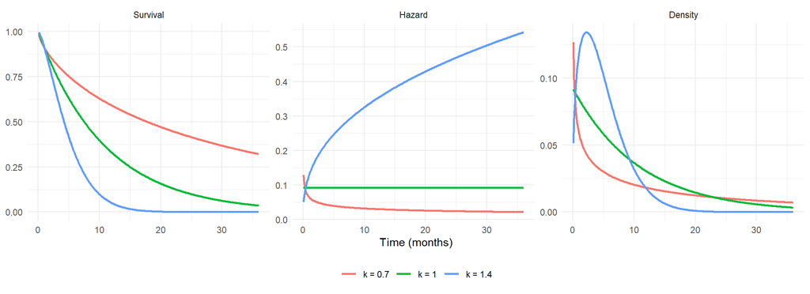

```r
lambda_exp <- log(2) / TARGET_MEDIAN_Z0
t_grid     <- seq(0.1, 36, by = 0.1)

curves <- tidyr::expand_grid(time = t_grid, k = c(0.7, 1, 1.4)) |>
  mutate(
    Survival = exp(-lambda_exp * time^k),
    Hazard   = lambda_exp * k * time^(k - 1),
    Density  = Hazard * Survival,
    shape    = factor(paste0("k = ", k))
  ) |>
  pivot_longer(c(Survival, Hazard, Density), names_to = "quantity") |>
  mutate(quantity = factor(quantity, levels = c("Survival", "Hazard", "Density")))

ggplot(curves, aes(time, value, colour = shape)) +
  geom_line(linewidth = 0.9) +
  facet_wrap(~ quantity, scales = "free_y") +
  labs(x = "Time (months)", y = NULL, colour = NULL) +
  theme_minimal() +
  theme(legend.position = "bottom")
```

## 9.2 Latent survival in the generated populations

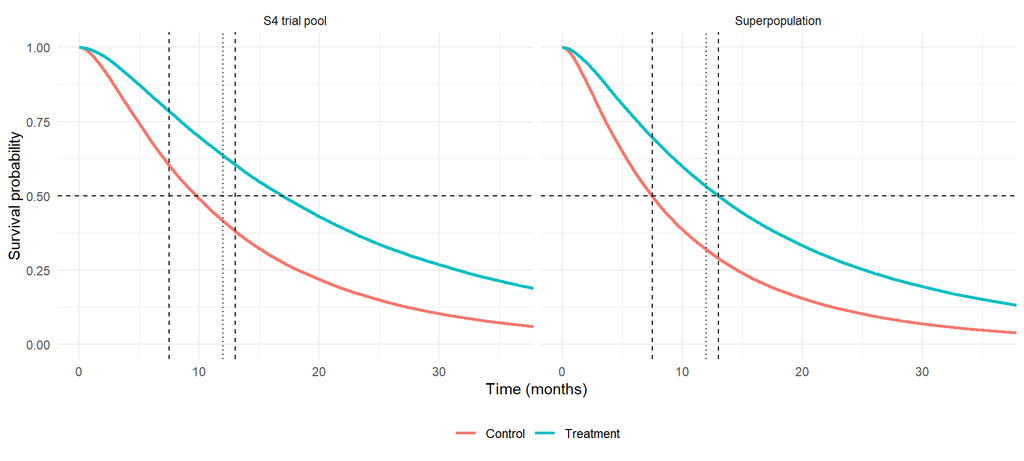

```r
latent_curve <- function(dat, pop) {
  purrr::map_dfr(c(Control = "T_true_z0", Treatment = "T_true_z1"), function(v) {
    fit <- survfit(Surv(dat[[v]], rep(1, nrow(dat))) ~ 1)
    tibble(time = fit$time, surv = fit$surv)
  }, .id = "arm") |>
    mutate(population = pop)
}

bind_rows(
  latent_curve(superpopulation_generated, "Superpopulation"),
  latent_curve(trial_pool_s4,             "S4 trial pool")
) |>
  ggplot(aes(time, surv, colour = arm)) +
  geom_step(linewidth = 0.9) +
  geom_hline(yintercept = 0.5, linetype = "dashed") +
  geom_vline(xintercept = c(TARGET_MEDIAN_Z0, TARGET_MEDIAN_Z1), linetype = "dashed") +
  geom_vline(xintercept = TAU, linetype = "dotted") +
  facet_wrap(~ population) +
  coord_cartesian(xlim = c(0, 36)) +
  labs(x = "Time (months)", y = "Survival probability", colour = NULL) +
  theme_minimal() +
  theme(legend.position = "bottom")
```